# Cahier des charges

Cédric Octave ADECHINA, Maxime DE BONI, Antônio Gabriel ELEUTERIO VIANA, Thomas FERNANDEZ, Diamande DELANNAY, Zineb BELMADAN

15 February 2024

## Introduction

L’objectif de notre projet est de développer une application permettant aux utilisateurs de créer des recettes en sélectionnant des ingrédients, tout en fournissant des informations nutritionnelles sur les recettes générées.le temps de préparation ainsi que l’origine de la recette

# Objectifs et fonctionnalités

1. Reherche de Recettes Permettre aux utilisateurs de rechercher des recettes en fonction d’ingrédients selectionnés.
2. Affichage des Détails Afficher les détails des recettes sélectionnées, y compris les instructions de préparation, le temps nécessaire, etc.
3. Filtrage Avancé Intégrer des filtres avancés tels que les calories, les protéines, les glucides,le temps de préparation, l’origine du plat, etc..
4. Prooposer en tous 42 recettes à partir de 6 ingrédients de base

# Outils

L’application sera développé en utilisant les technologies suivantes

-Shiny :Nous avons utilisé ce framework interactif pour R grâce au language statistique puissant pour créer une interface utilisateur interactive -R :Ce langage nous a permis la manipulation des données avec son vaste ensemble de packages dédiées à celà. ce qui facilite le traitement et la visualisation des informations liées aux recettes proposéés. -Github :La plateforme de développement collaboratif basée sur Git nous a faciliter le travail d’équipe et a permis le suivi des modifications apportées au code source. -Rstudio :L’environnement de développement nous a offert une interface utilisateur pour la programmation offrant de différentes fonctionnalités puissantes.

# Packages:

1. Shinydashboard: est un package R conçu pour créer des tableau de bord interactifs dans shiny.
2. DT: Le package DataTables est utilisé pour afficher des tableaux de données interactifs dans shiny, offre plusieurs fonctionnalités comme la recherche, le tri, etc..
3. Shiny: le package permet de créer des application web interactives en R. Il permet la gestion des entrées, et la création d’une interface utilisateur interactive

# Calendrier

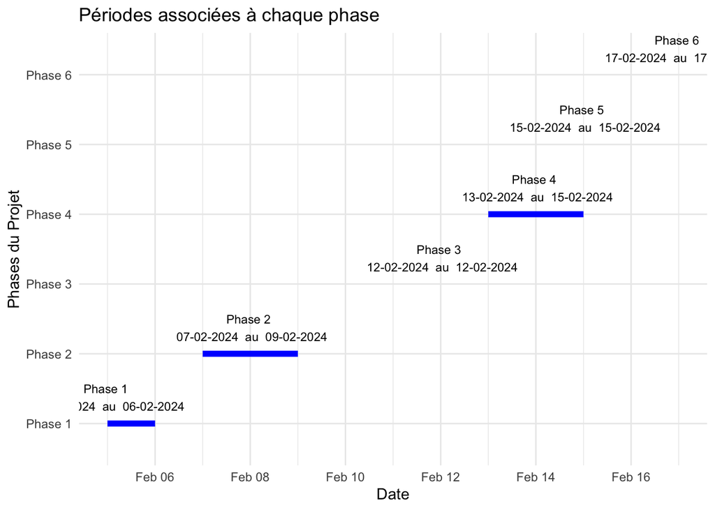

```
##     Phase      Start        End
## 1 Phase 1 2024-02-05 2024-02-06
## 2 Phase 2 2024-02-07 2024-02-09
## 3 Phase 3 2024-02-12 2024-02-12
## 4 Phase 4 2024-02-13 2024-02-15
## 5 Phase 5 2024-02-15 2024-02-15
## 6 Phase 6 2024-02-17 2024-02-17
```

[figure not shown]

# Design et interface utilisateur

L’interface utilisateur doit être conviviale et intuitive, avec des menus déroulants clairement étiquetés et des boutons d’action facilement accessibles.

Les résultats de recherche doivent être présentés de manière claire et organisée dans un tableau interactif.

Les détails des recettes sélectionnées doivent être affichés dans une fenêtre modale avec un bouton pour fermer la fenêtre.

L’application comprendra les pages suivantes : - Page 1: Page d’accueil - Page 2: Choix de la recette - Page 3: Instructions

# Liste déroulante des pays

Nous présentons en premier lieu la carte des Pays spécifiques choisis pour les recettes.

[interactive chart not shown]

# Liste déroulante des ingrédients